# ggplot2

**ggplot2** is a system for creating graphics based on The Grammar of Graphics:

- Provide the data.
- tell ggplot2 how to map variables to aesthetics.
- tell what graphical primitives to use.

To illustrate how can we create plots with ggplot, we will use the nycflights13 data. We will also load some other packages to handle data:

```r
library(dplyr)
library(data.table)
library(ggplot2)
library(nycflights13)
```

# 1 The data

```r
flights
```

```
## # A tibble: 336,776 x 19
##     year month   day dep_t… sched_… dep_d… arr_… sched… arr_d… carr… flig…
##    <int> <int> <int>  <int>   <int>  <dbl> <int>  <int>  <dbl> <chr> <int>
##  1  2013     1     1    517     515   2.00   830    819  11.0  UA     1545
##  2  2013     1     1    533     529   4.00   850    830  20.0  UA     1714
##  3  2013     1     1    542     540   2.00   923    850  33.0  AA     1141
##  4  2013     1     1    544     545  -1.00  1004   1022 -18.0  B6      725
##  5  2013     1     1    554     600  -6.00   812    837 -25.0  DL      461
##  6  2013     1     1    554     558  -4.00   740    728  12.0  UA     1696
##  7  2013     1     1    555     600  -5.00   913    854  19.0  B6      507
##  8  2013     1     1    557     600  -3.00   709    723 -14.0  EV     5708
##  9  2013     1     1    557     600  -3.00   838    846 - 8.00 B6       79
## 10  2013     1     1    558     600  -2.00   753    745   8.00 AA      301
## # ... with 336,766 more rows, and 8 more variables: tailnum <chr>, origin
## #   <chr>, dest <chr>, air_time <dbl>, distance <dbl>, hour <dbl>, minute
## #   <dbl>, time_hour <dttm>
```

```r
names(flights)
```

```
##  [1] "year"           "month"          "day"            "dep_time"
##  [5] "sched_dep_time" "dep_delay"      "arr_time"       "sched_arr_time"
##  [9] "arr_delay"      "carrier"        "flight"         "tailnum"
## [13] "origin"         "dest"           "air_time"       "distance"
## [17] "hour"           "minute"         "time_hour"
```

We can be interested obtaining the following variables for every hour (that is, for every unique `year`, `month`, `day` and `hour`) and every `origin` (as we have three diferent origin airports in this database):

- Average departure delay `av_dep`.
- Average arrival delay `av_arr`.
- The number of flights `traff`.

We can do that using `data.table`:

```r
flights.dt <- as.data.table(flights)
av.delays.dt <- flights.dt[!is.na(dep_delay) & !is.na(arr_delay) , .(av_dep=mean(dep_delay), av_arr=mean(arr_delay), traffic=.N), by=  .(year, month, day, hour, origin)]
```

… or using `dplyr`:

```r
av.delays <- flights %>% filter(!is.na(dep_delay) & !is.na(arr_delay)) %>% group_by(year, month, day, hour, origin) %>% summarise(av_dep=mean(dep_delay), av_arr=mean(arr_delay), traffic=n())
```

```r
av.delays.dt
```

```
##        year month day hour origin      av_dep     av_arr traffic
##     1: 2013     1   1    5    EWR  -1.0000000  11.500000       2
##     2: 2013     1   1    5    LGA   4.0000000  20.000000       1
##     3: 2013     1   1    5    JFK   0.3333333   3.666667       3
##     4: 2013     1   1    6    LGA   4.2352941  11.647059      17
##     5: 2013     1   1    6    EWR   3.0555556   1.888889      18
##    ---
## 19428: 2013     9  30   21    EWR   4.8000000  -7.800000      10
## 19429: 2013     9  30   21    JFK   0.0000000 -28.571429       7
## 19430: 2013     9  30   22    LGA  -2.0000000   8.000000       1
## 19431: 2013     9  30   22    JFK  -5.0000000 -13.500000       6
## 19432: 2013     9  30   23    JFK -10.0000000 -25.000000       1
```

```r
av.delays
```

```
## # A tibble: 19,432 x 8
## # Groups: year, month, day, hour [?]
##     year month   day  hour origin  av_dep  av_arr traffic
##    <int> <int> <int> <dbl> <chr>    <dbl>   <dbl>   <int>
##  1  2013     1     1  5.00 EWR    - 1.00   11.5         2
##  2  2013     1     1  5.00 JFK      0.333   3.67        3
##  3  2013     1     1  5.00 LGA      4.00   20.0         1
##  4  2013     1     1  6.00 EWR      3.06    1.89       18
##  5  2013     1     1  6.00 JFK    - 1.06  - 2.44       16
##  6  2013     1     1  6.00 LGA      4.24   11.6        17
##  7  2013     1     1  7.00 EWR     14.2    12.6        12
##  8  2013     1     1  7.00 JFK      4.12    1.75       16
##  9  2013     1     1  7.00 LGA    - 3.05    0.238      21
## 10  2013     1     1  8.00 EWR      0.750 - 3.50       20
## # ... with 19,422 more rows
```

# 2 A ggplot graphic

To obtain a **ggplot** graph we need:

- to pass the data and map the aesthetics with the **ggplot** function
- to tell the primitives to use.

As we will see, each primitive is associated to an aesthetic.

Let’s make a density plot of the arrival delay:

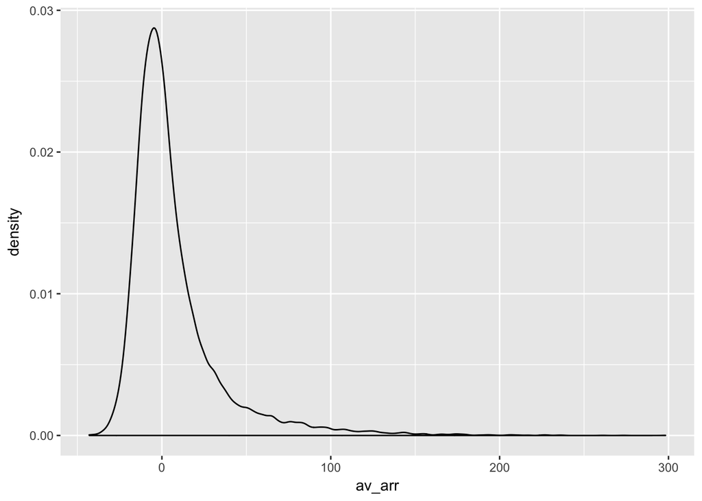

```r
ggplot(av.delays.dt, aes(av_arr)) + geom_density()
```

We can make the same plot, with a lines in blue and density fill in green:

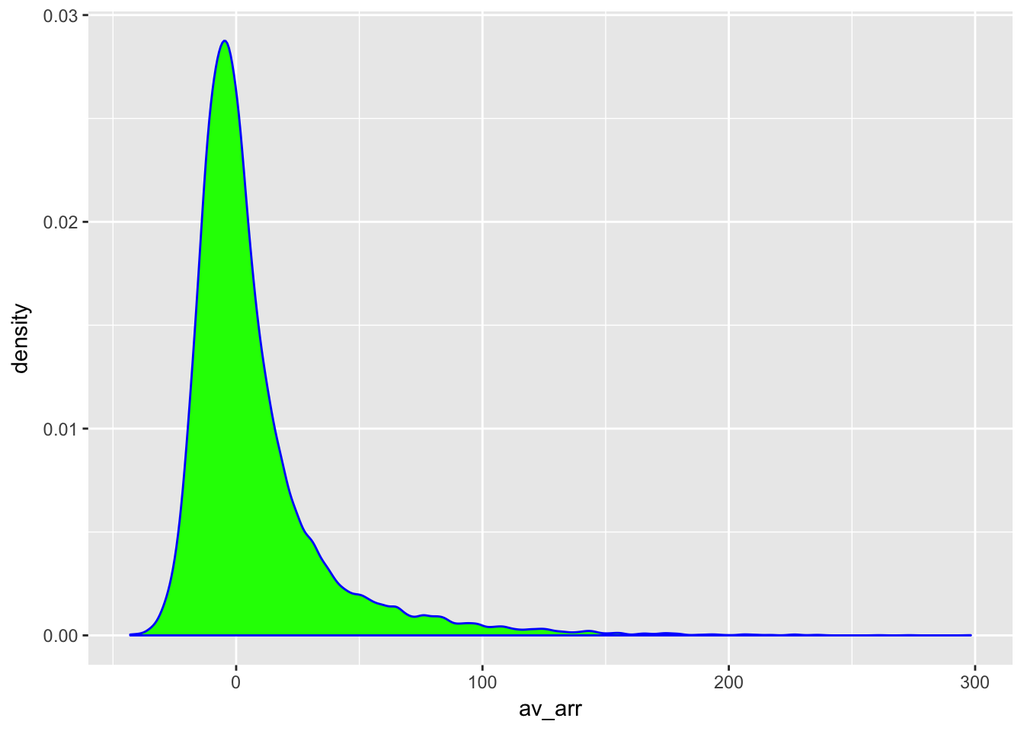

```r
ggplot(av.delays.dt, aes(av_arr)) + geom_density(color="blue", fill="green")
```

with a different theme:

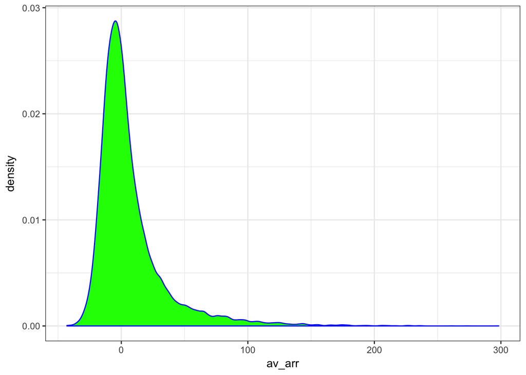

```r
ggplot(av.delays.dt, aes(av_arr)) + geom_density(color="blue", fill="green") + theme_bw()
```

with a larger font size:

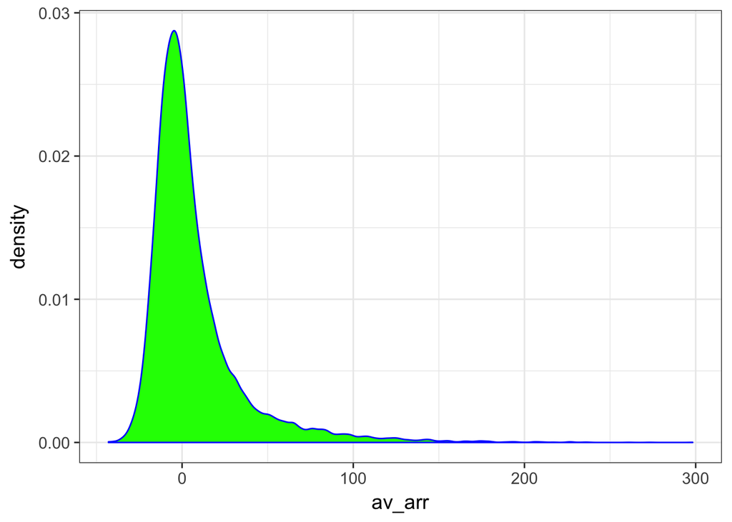

```r
ggplot(av.delays.dt, aes(av_arr)) + geom_density(color="blue", fill="green") + theme_bw(base_size = 14)
```

Note that we can use a `data.table` as input of a ggplot graphic.

# 3 One variable

## 3.1 Barplots

We can count how many elements are in each category with a barplot.Here we can count how many flights are flown by each carrier. To do so we use the original dataset:

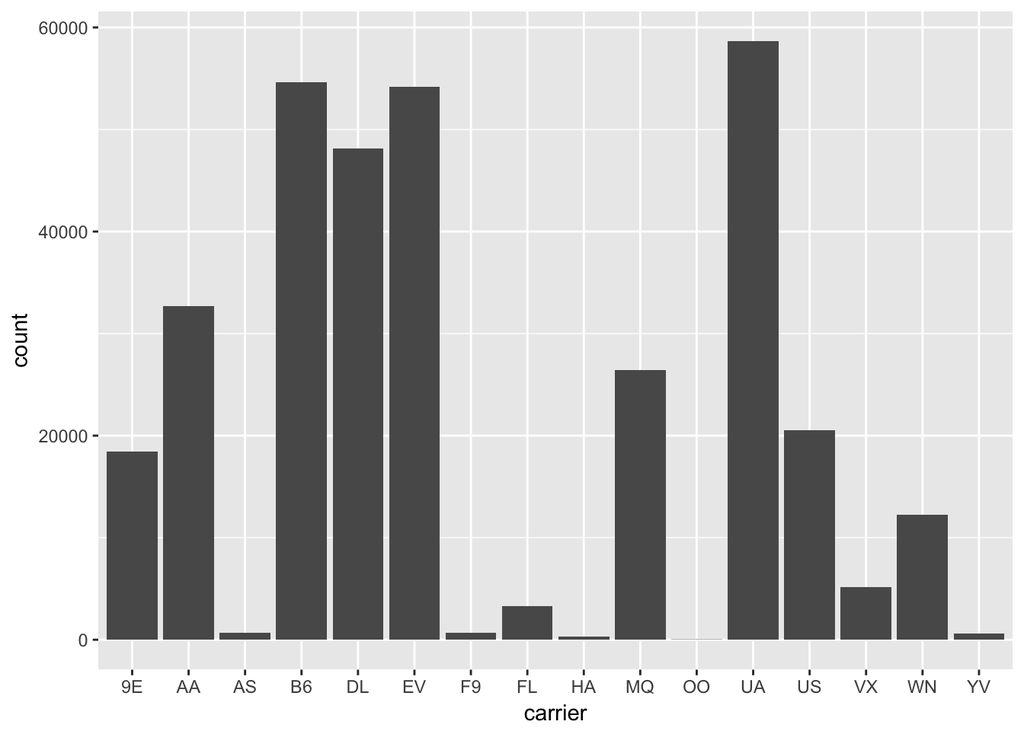

```r
ggplot(flights, aes(carrier)) + geom_bar()
```

Note that the easthetic is a categorical variable, and that we count how many elements there are to make the barplot.

Perhaps we can be interested in knowing how much flights sends each airline. To do so we put a color in the aesthetic equal to the `origin` variable. Then we plot the results for each category in a different color:

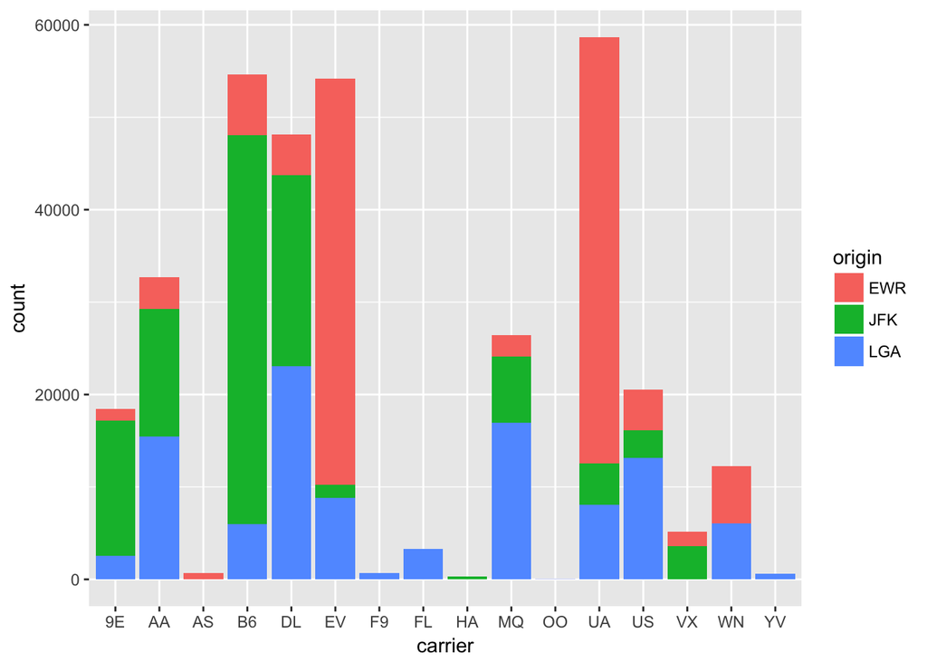

```r
ggplot(flights, aes(carrier, fill=origin)) + geom_bar()
```

We can have alternative presentations:

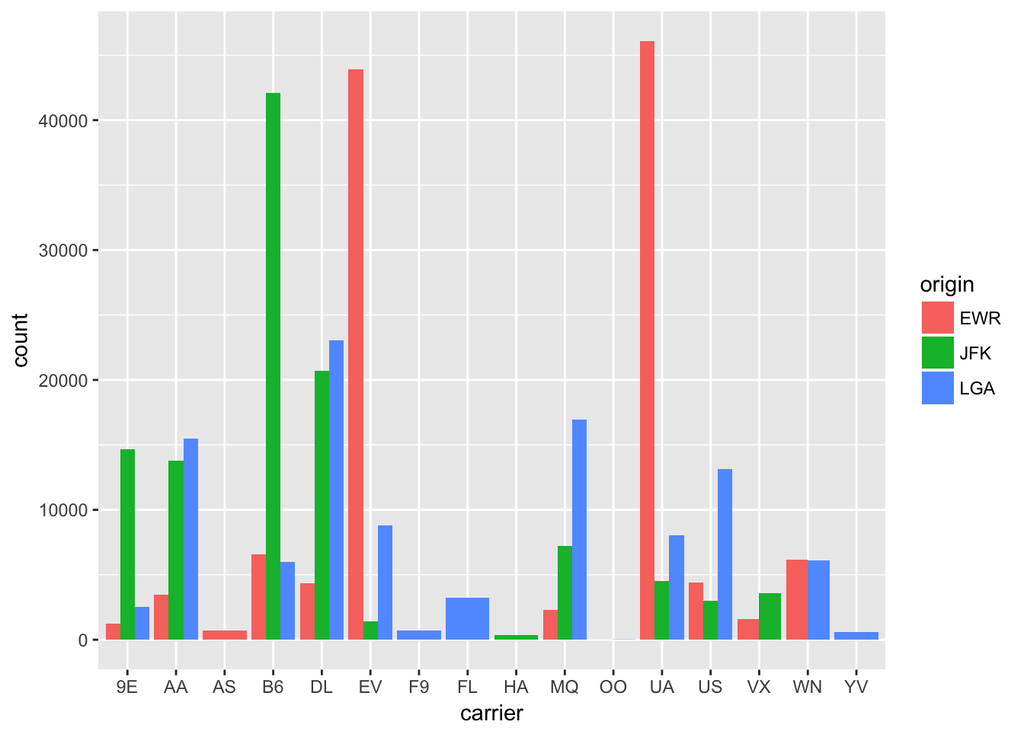

```r
ggplot(flights, aes(carrier, fill=origin)) + geom_bar(position = "dodge")
```

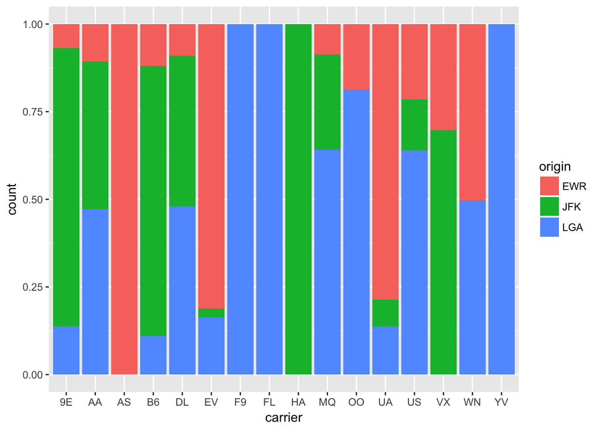

```r
ggplot(flights, aes(carrier, fill=origin)) + geom_bar(position = "fill")
```

## 3.2 Histograms

In addition to density plots, we can make histograms:

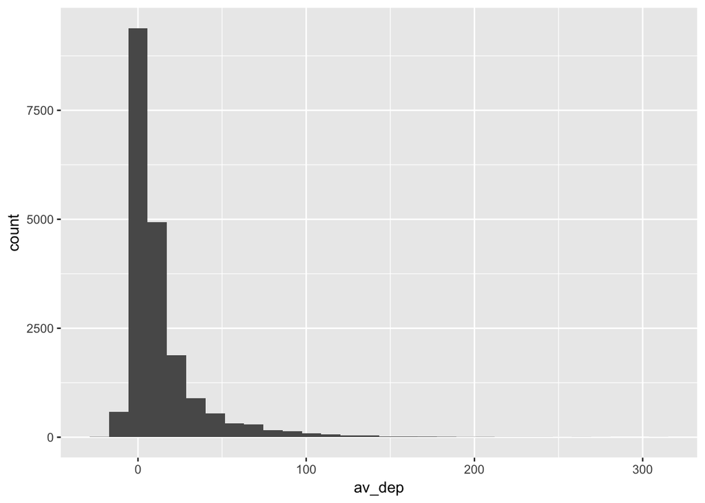

```r
ggplot(av.delays.dt, aes(av_dep)) + geom_histogram()
```

# 4 Discrete variable, continuous variable

We can evaluate a continuous variable, say `av_arr` as a function of a categorical variable, the `origin` airport.

## 4.1 Barplots

For instance, we can evaluate the traffic of each origin:

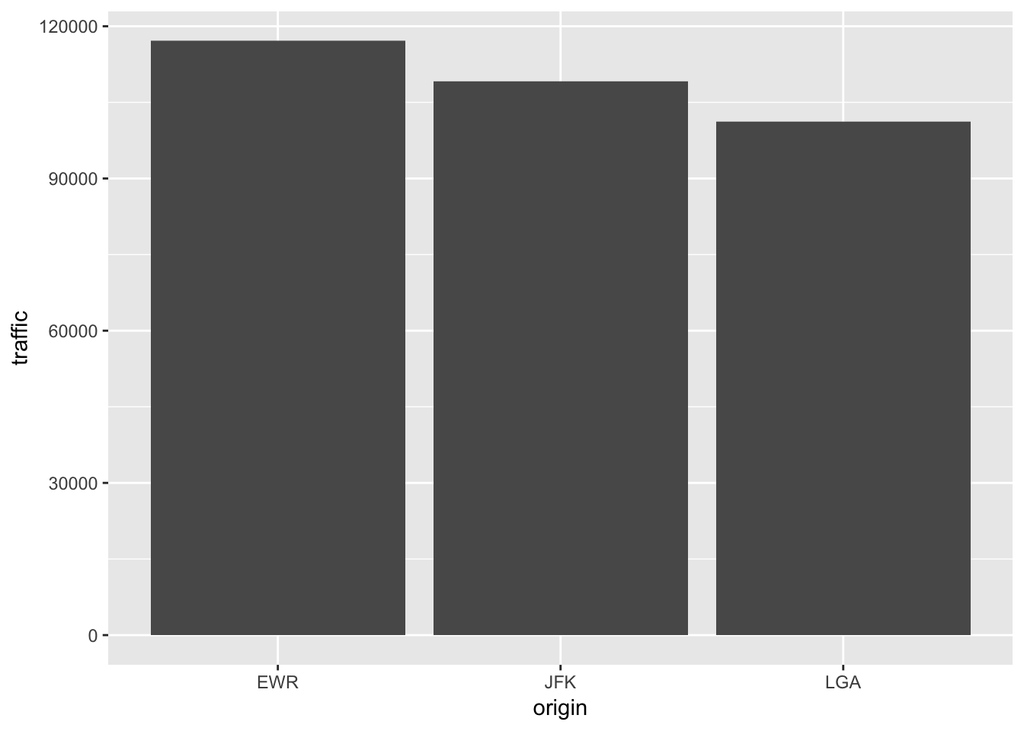

```r
ggplot(av.delays.dt, aes(origin, traffic)) + geom_bar(stat = "identity")
```

## 4.2 Boxplot and violin plots

For variables like `av_arr` a boxplot can be more useful:

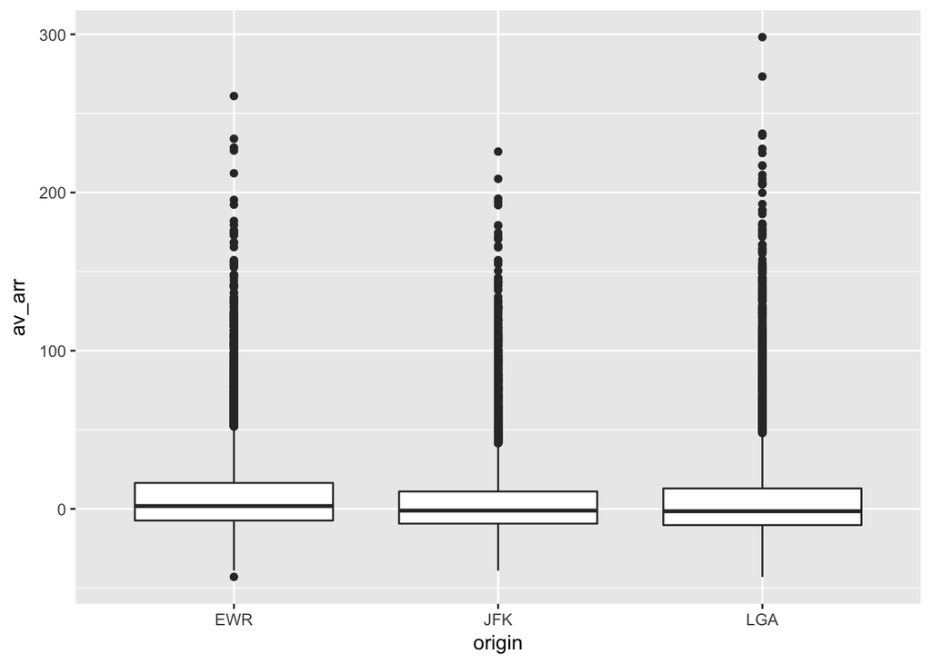

```r
ggplot(av.delays.dt, aes(origin, av_arr)) + geom_boxplot()
```

…or perhaps:

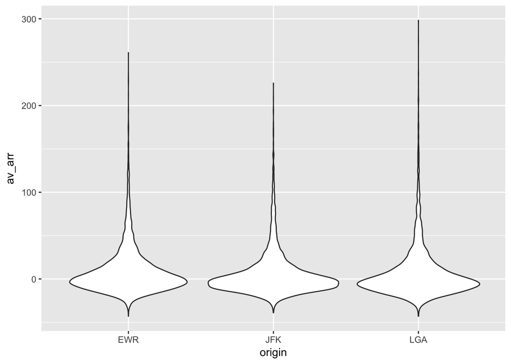

```r
ggplot(av.delays.dt, aes(origin, av_arr)) + geom_violin()
```

looks nicer this way:

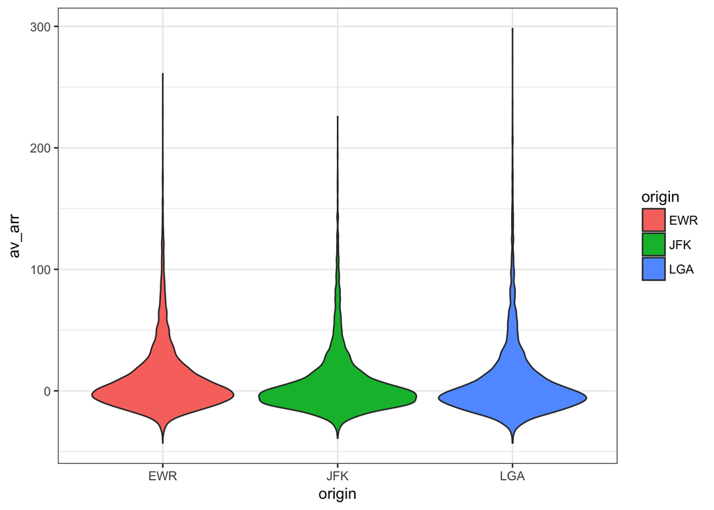

```r
ggplot(av.delays.dt, aes(origin, av_arr, fill=origin)) + geom_violin() + theme_bw()
```

# 5 Two continuous variables

## 5.1 Scatterplots

We can be interested in checking the relationship between arrival and departure delays for each hour segment, so every observation is a point in a scatterplot. We can also let ggplot draw a tendency line with `geom_smooth`:

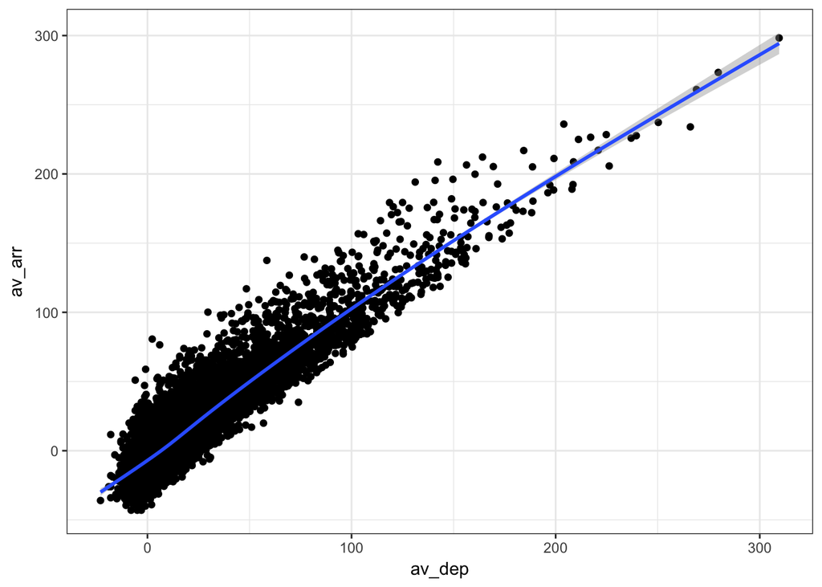

```r
ggplot(av.delays.dt, aes(av_dep, av_arr)) + geom_point() + geom_smooth() + theme_bw()
```

And we can do the same for each origin, plotting it in a different color:

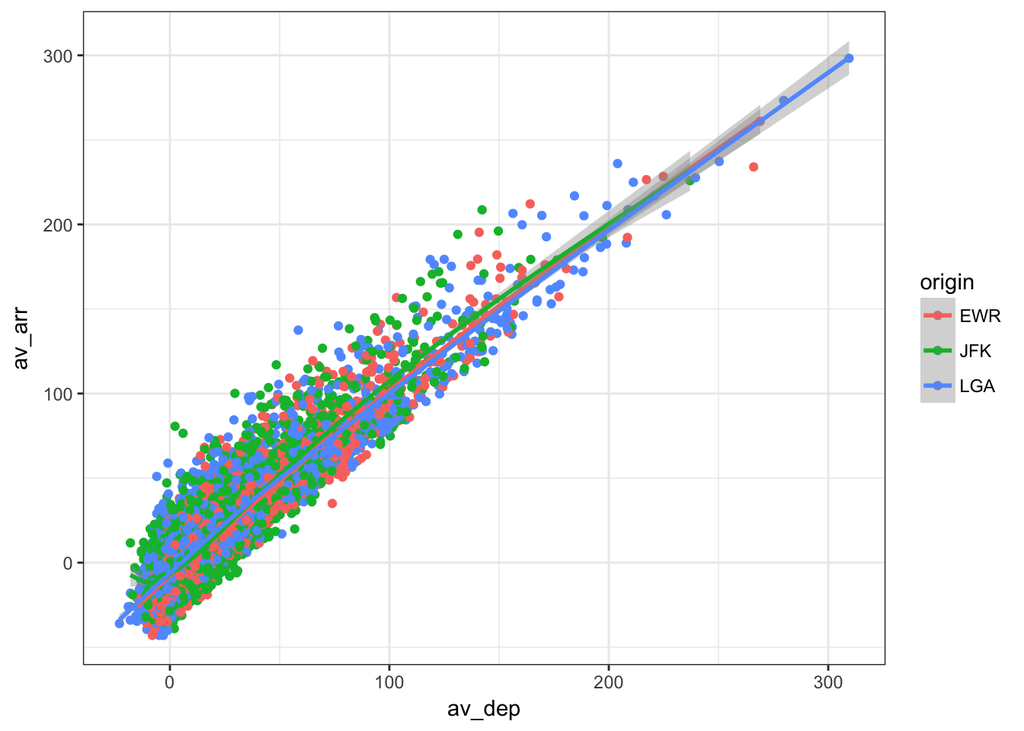

```r
ggplot(av.delays.dt, aes(av_dep, av_arr, color=origin)) + geom_point() + geom_smooth() + theme_bw()
```

## 5.2 Two-density plots

Similarly to one-density plots, we can draw density plots of bivariates:

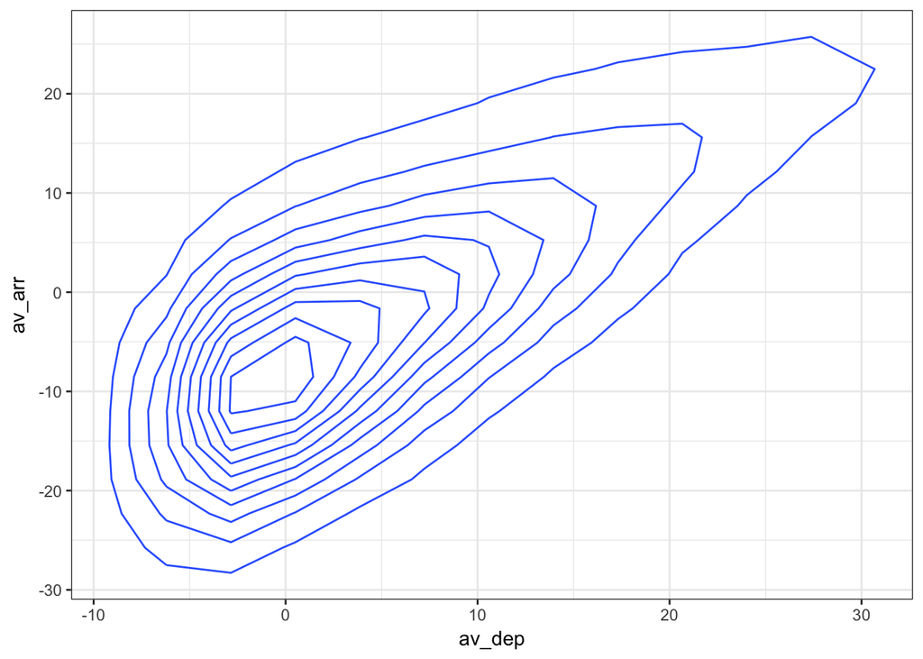

```r
ggplot(av.delays.dt, aes(av_dep, av_arr)) + geom_density_2d() + theme_bw()
```

# 6 Facet grids

When we make plots with categories, we might want to get one plot for each category instead of a plot for each category. We can achieve this with `facet_grid`. We can make grids by rows, by columns, or both. Let’s see it with several scatterplots:

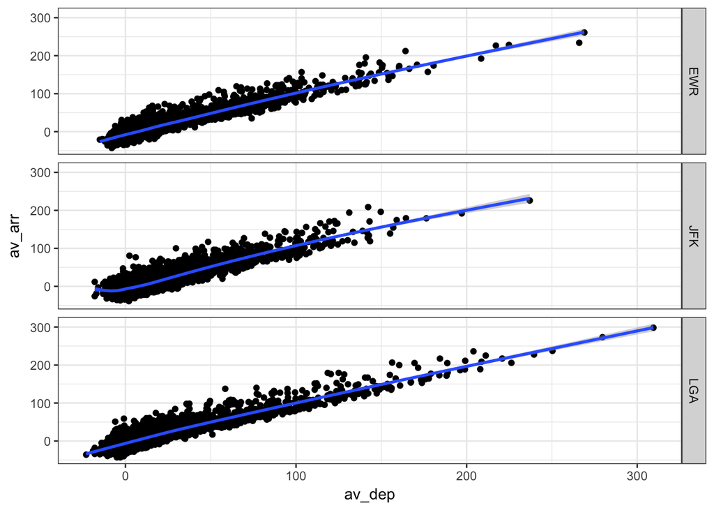

```r
ggplot(av.delays.dt, aes(av_dep, av_arr)) + geom_point() + geom_smooth() + theme_bw() + facet_grid(origin ~ .)
```

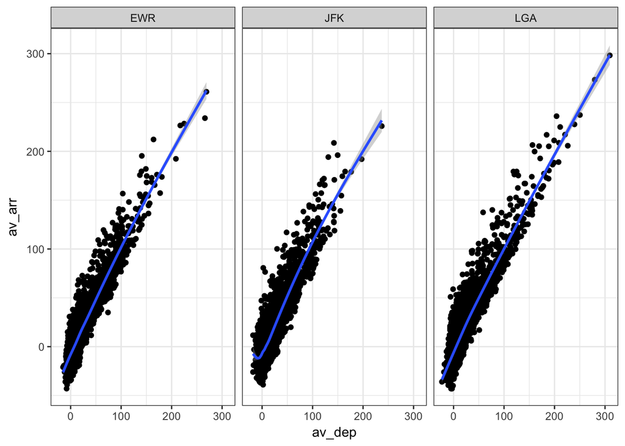

```r
ggplot(av.delays.dt, aes(av_dep, av_arr)) + geom_point() + geom_smooth() + theme_bw() + facet_grid(. ~ origin)
```